# Oral microbial signatures of head and neck cancer patients with diverse longitudinal disease severity patterns

# Identifying underlying patient characteristics that are driving patient groups

To investigate whether specific clinical features contributed to differences between patient groups, we first visualized marginal density plots for relevant variables such as age, weight, and BMI. Where visual differences between groups were apparent, we performed two-sample t-tests to formally assess differences across cluster combinations. Assumptions of normality and homogeneity of variance were checked prior to conducting the tests.

```r
# Load patient characteristics
clFeat <- readr::read_csv("data/age_final_data.csv")
clFeat <- merge(df[,c("id","cluster")], clFeat, by = "id")
```

```r
clFeat$cluster <- as.factor(clFeat$cluster)
clFeat$bmi <- clFeat$weight/clFeat$heightnew^2
table(clFeat$cluster)
```

```
##
##  1  2  3
## 29 47 61
```

```r
clFeat %>% group_by(cluster) %>% summarise_all(mean, na.rm = TRUE)
```

| cluster | id | partid | sex | height | weight | highest_grade | marital_status | current_employment | spanish_hispanic_latino | race___1 | race___2 | race___3 | race___4 | race___5 | race___6 | race___99 | age | trajgroup | bmi | heightnew |
| --- | --- | --- | --- | --- | --- | --- | --- | --- | --- | --- | --- | --- | --- | --- | --- | --- | --- | --- | --- | --- |
| 1 | NA | NA | 1.862069 | NA | 185.8276 | 3.517241 | 1.172414 | 1.793103 | 1.310345 | 0.8965517 | 0.06896552 | 0.00000000 | 0 | 0.03448276 | 0.00000000 | 0 | 59.68966 | 3.172414 | 0.04019284 | 68.12069 |
| 2 | NA | NA | 1.957447 | NA | 205.2553 | 3.404255 | 1.382979 | 1.595745 | 1.638298 | 0.9148936 | 0.02127660 | 0.00000000 | 0 | 0.00000000 | 0.12765957 | 0 | 56.53191 | 2.531915 | 0.04237349 | 69.59574 |
| 3 | NA | NA | 1.901639 | NA | 201.5574 | 3.688525 | 1.295082 | 1.573770 | 1.377049 | 0.9180328 | 0.01639344 | 0.04918033 | 0 | 0.00000000 | 0.03278689 | 0 | 58.08197 | 3.000000 | 0.04113945 | 69.94098 |

```r
table(clFeat$cluster)
```

```
##
##  1  2  3
## 29 47 61
```

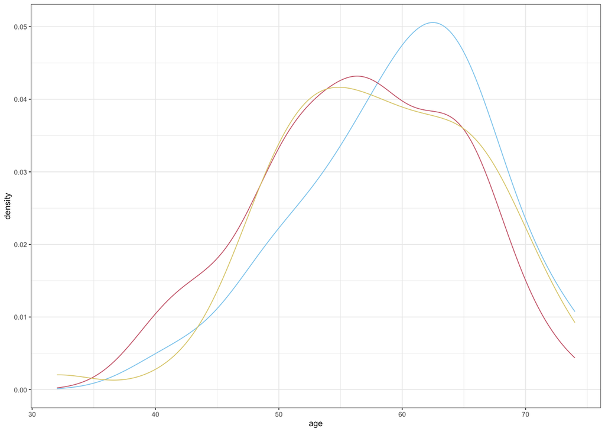

```r
clFeat %>% ggplot(aes(age)) + geom_density(aes(colour = cluster),show.legend = FALSE)+
  theme_bw(base_size = 7)+
    scale_color_manual(values = carto_pal(n=5, "Safe"))
```

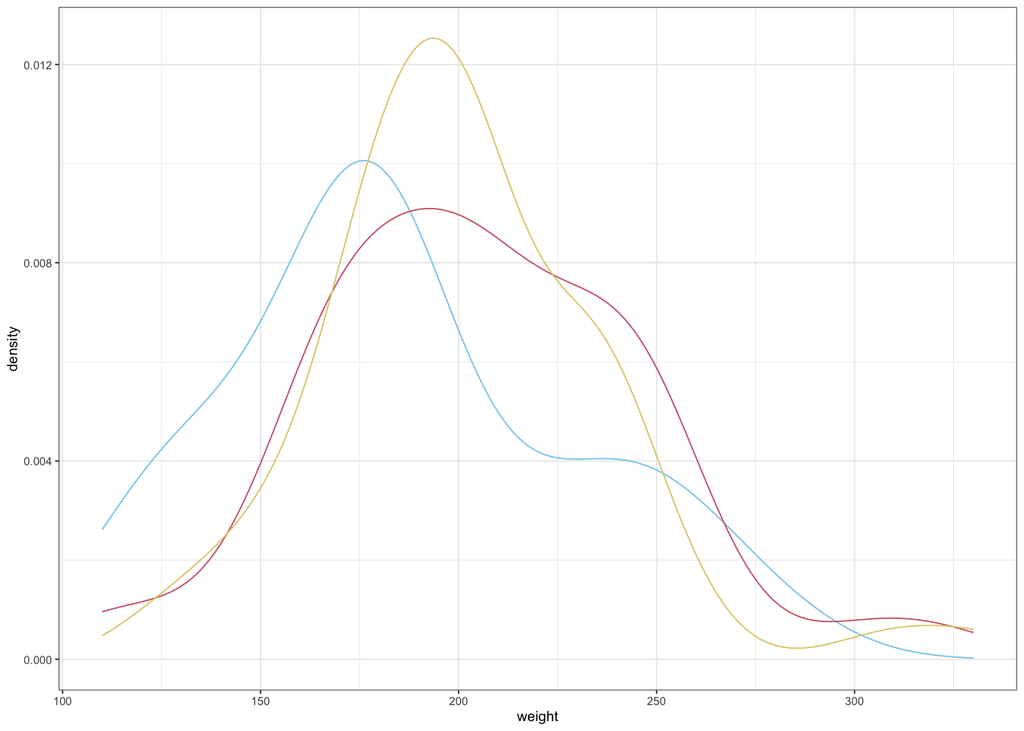

```r
ggsave("figs/age.png", width = 3, height = 2.5)

clFeat %>% ggplot(aes(weight)) + geom_density(aes(colour = cluster),show.legend = FALSE)+
  theme_bw(base_size = 7)+
    scale_color_manual(values = carto_pal(n=5, "Safe"))
```

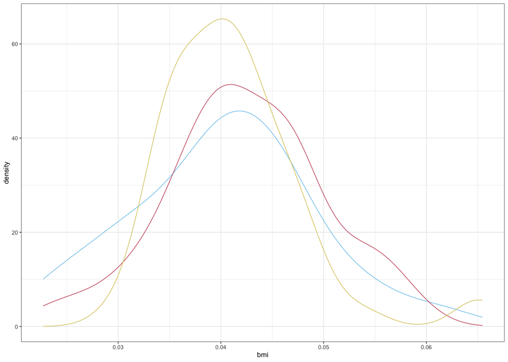

```r
ggsave("figs/weight.png", width = 3, height = 2.5)


clFeat %>% ggplot(aes(bmi)) + geom_density(aes(colour = cluster), show.legend = FALSE)+
  theme_bw(base_size = 7)+
    scale_color_manual(values = carto_pal(n=5, "Safe"))
```

```r
# Age- (pvalue 0.04682)
data1 <- clFeat$age[clFeat$cluster == 1]
data2 <- clFeat$age[clFeat$cluster == 2]
  # Normality ( pvalues 0.857, 0.3249)
  shapiro.test(data1);shapiro.test(data2)
```

```
##
##  Shapiro-Wilk normality test
##
## data:  data1
## W = 0.98076, p-value = 0.857
```

```
##
##  Shapiro-Wilk normality test
##
## data:  data2
## W = 0.97236, p-value = 0.3249
```

```r
  # Equal variance (pvalue 0.927)
  var.test(data1, data2)
```

```
##
##  F test to compare two variances
##
## data:  data1 and data2
## F = 0.96006, num df = 28, denom df = 46, p-value = 0.927
## alternative hypothesis: true ratio of variances is not equal to 1
## 95 percent confidence interval:
##  0.5022552 1.9407832
## sample estimates:
## ratio of variances
##          0.9600622
```

```r
t.test(data1, data2, var.equal = T, alternative = "greater")
```

```
##
##  Two Sample t-test
##
## data:  data1 and data2
## t = 1.6983, df = 74, p-value = 0.04682
## alternative hypothesis: true difference in means is greater than 0
## 95 percent confidence interval:
##  0.06068477        Inf
## sample estimates:
## mean of x mean of y
##  59.68966  56.53191
```

```r
# Age- (pvalue 0.1907)
data1 <- clFeat$age[clFeat$cluster == 1]
data2 <- clFeat$age[clFeat$cluster == 3]
  # Normality ( pvalues 0.857, 0.3533)
  shapiro.test(data1);shapiro.test(data2)
```

```
##
##  Shapiro-Wilk normality test
##
## data:  data1
## W = 0.98076, p-value = 0.857
```

```
##
##  Shapiro-Wilk normality test
##
## data:  data2
## W = 0.97839, p-value = 0.3533
```

```r
  # Equal variance (pvalue 0.746)
  var.test(data1, data2)
```

```
##
##  F test to compare two variances
##
## data:  data1 and data2
## F = 0.88777, num df = 28, denom df = 60, p-value = 0.7463
## alternative hypothesis: true ratio of variances is not equal to 1
## 95 percent confidence interval:
##  0.4838938 1.7574673
## sample estimates:
## ratio of variances
##          0.8877654
```

```r
t.test(data1, data2, var.equal = T, alternative = "greater")
```

```
##
##  Two Sample t-test
##
## data:  data1 and data2
## t = 0.87972, df = 88, p-value = 0.1907
## alternative hypothesis: true difference in means is greater than 0
## 95 percent confidence interval:
##  -1.430279       Inf
## sample estimates:
## mean of x mean of y
##  59.68966  58.08197
```

```r
# Age- (pvalue 0.8364)
data1 <- clFeat$age[clFeat$cluster == 2]
data2 <- clFeat$age[clFeat$cluster == 3]
  # Normality ( pvalues 0.3249, 0.3533)
  shapiro.test(data1);shapiro.test(data2)
```

```
##
##  Shapiro-Wilk normality test
##
## data:  data1
## W = 0.97236, p-value = 0.3249
```

```
##
##  Shapiro-Wilk normality test
##
## data:  data2
## W = 0.97839, p-value = 0.3533
```

```r
  # Equal variance (pvalue 0.788)
  var.test(data1, data2)
```

```
##
##  F test to compare two variances
##
## data:  data1 and data2
## F = 0.9247, num df = 46, denom df = 60, p-value = 0.7884
## alternative hypothesis: true ratio of variances is not equal to 1
## 95 percent confidence interval:
##  0.5392925 1.6177602
## sample estimates:
## ratio of variances
##          0.9246957
```

```r
t.test(data1, data2, var.equal = T, alternative = "greater")
```

```
##
##  Two Sample t-test
##
## data:  data1 and data2
## t = -0.98416, df = 106, p-value = 0.8364
## alternative hypothesis: true difference in means is greater than 0
## 95 percent confidence interval:
##  -4.163546       Inf
## sample estimates:
## mean of x mean of y
##  56.53191  58.08197
```

```r
# Weight (pvalue 0.02683)
data1 <- clFeat$weight[clFeat$cluster == 1]
data2 <- clFeat$weight[clFeat$cluster == 2]
  # Normality ( pvalues 0.1304, 0.4293)
  shapiro.test(data1);shapiro.test(data2)
```

```
##
##  Shapiro-Wilk normality test
##
## data:  data1
## W = 0.94436, p-value = 0.1304
```

```
##
##  Shapiro-Wilk normality test
##
## data:  data2
## W = 0.97573, p-value = 0.4293
```

```r
  # Equal variance (pvalue 0.7883)
  var.test(data1, data2)
```

```
##
##  F test to compare two variances
##
## data:  data1 and data2
## F = 1.0854, num df = 28, denom df = 46, p-value = 0.7883
## alternative hypothesis: true ratio of variances is not equal to 1
## 95 percent confidence interval:
##  0.5678465 2.1942369
## sample estimates:
## ratio of variances
##            1.08544
```

```r
t.test(data1, data2, var.equal = T, alternative = "less")
```

```
##
##  Two Sample t-test
##
## data:  data1 and data2
## t = -1.9609, df = 74, p-value = 0.02683
## alternative hypothesis: true difference in means is less than 0
## 95 percent confidence interval:
##       -Inf -2.924884
## sample estimates:
## mean of x mean of y
##  185.8276  205.2553
```

```r
# Weight (pvalue 0.03713)
data1 <- clFeat$weight[clFeat$cluster == 1]
data2 <- clFeat$weight[clFeat$cluster == 3]
  # Normality ( pvalues 0.1304, 0.006892)
  shapiro.test(data1);shapiro.test(data2)
```

```
##
##  Shapiro-Wilk normality test
##
## data:  data1
## W = 0.94436, p-value = 0.1304
```

```
##
##  Shapiro-Wilk normality test
##
## data:  data2
## W = 0.94315, p-value = 0.006892
```

```r
  # Equal variance (pvalue 0.2749)
  var.test(data1, data2)
```

```
##
##  F test to compare two variances
##
## data:  data1 and data2
## F = 1.4, num df = 28, denom df = 60, p-value = 0.2749
## alternative hypothesis: true ratio of variances is not equal to 1
## 95 percent confidence interval:
##  0.7631038 2.7715376
## sample estimates:
## ratio of variances
##           1.400012
```

```r
t.test(data1, data2, var.equal = T, alternative = "less")
```

```
##
##  Two Sample t-test
##
## data:  data1 and data2
## t = -1.8064, df = 88, p-value = 0.03713
## alternative hypothesis: true difference in means is less than 0
## 95 percent confidence interval:
##       -Inf -1.254555
## sample estimates:
## mean of x mean of y
##  185.8276  201.5574
```

```r
# Weight (pvalue 0.6888)
data1 <- clFeat$weight[clFeat$cluster == 2]
data2 <- clFeat$weight[clFeat$cluster == 3]
  # Normality ( pvalues 0.4293, 0.006892)
  shapiro.test(data1);shapiro.test(data2)
```

```
##
##  Shapiro-Wilk normality test
##
## data:  data1
## W = 0.97573, p-value = 0.4293
```

```
##
##  Shapiro-Wilk normality test
##
## data:  data2
## W = 0.94315, p-value = 0.006892
```

```r
  # Equal variance (pvalue 0.3523)
  var.test(data1, data2)
```

```
##
##  F test to compare two variances
##
## data:  data1 and data2
## F = 1.2898, num df = 46, denom df = 60, p-value = 0.3523
## alternative hypothesis: true ratio of variances is not equal to 1
## 95 percent confidence interval:
##  0.7522313 2.2565303
## sample estimates:
## ratio of variances
##            1.28981
```

```r
t.test(data1, data2, var.equal = T, alternative = "less")
```

```
##
##  Two Sample t-test
##
## data:  data1 and data2
## t = 0.49387, df = 106, p-value = 0.6888
## alternative hypothesis: true difference in means is less than 0
## 95 percent confidence interval:
##     -Inf 16.1228
## sample estimates:
## mean of x mean of y
##  205.2553  201.5574
```

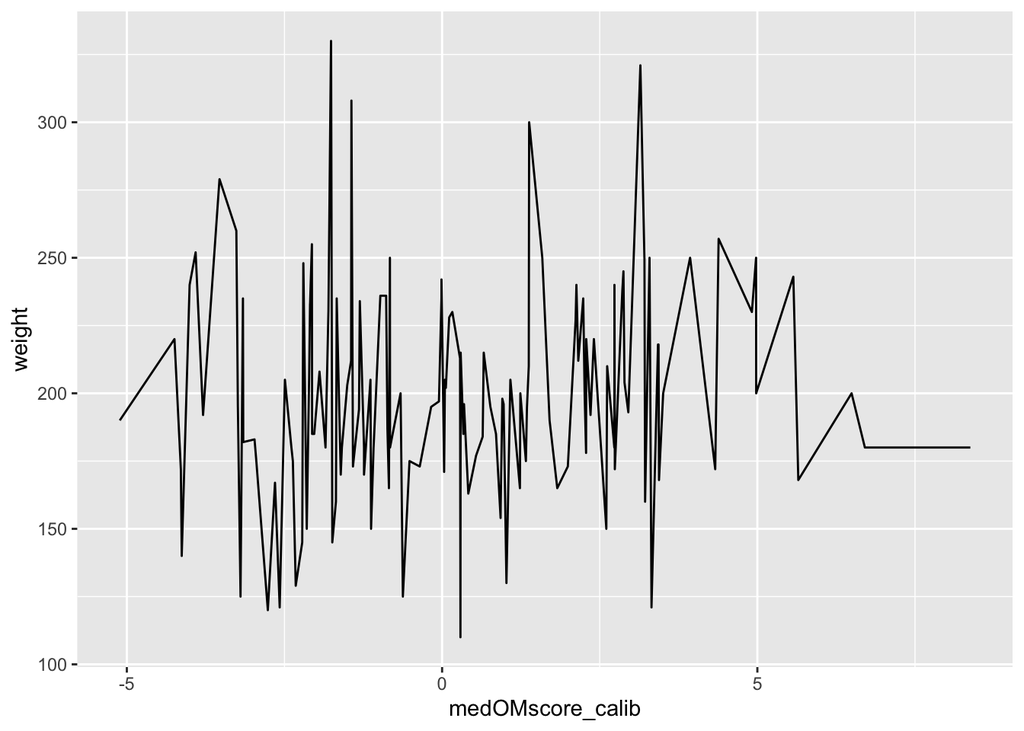

```r
# Investigate the relationship between calibrated OM score and age, weigh
medOMscore_calib <- metaDat_c %>% group_by(id) %>% summarise(medOMscore_calib = median(OMscore_calib))
clFeat <- merge(medOMscore_calib, clFeat, by = "id")
clFeat %>% ggplot(aes(medOMscore_calib, weight)) + geom_line()
```

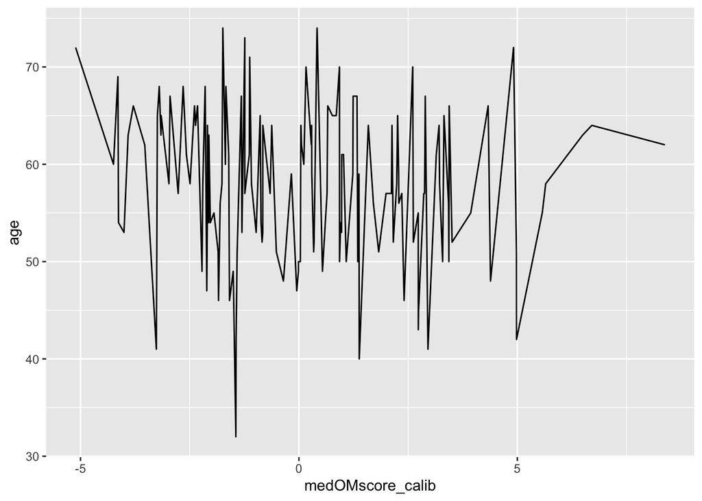

```r
clFeat %>% ggplot(aes(medOMscore_calib, age)) + geom_line()
```

# Identifying microbial features associated with calibrated OM score.

To identify microbial features associated with calibrated OM scores, we used a novel variable selection method, partial least squares knockoff (PLSKO). PLSKO is a knock-off variable selection method based on PLS regression. We opted for a knock-off-based approach for variable selection since knock-off approaches provide statistically principled false discovery control, whereas alternative methods such as lasso and sparse PLS lack. We first applied PLSKO to the whole dataset to identify OTUs correlated with the calibrated OM score across all patients. Then, we applied PLSKO to each individual cluster of patients to uncover group-specific OTUs.

```r
# Prepare data
taxonomy_table <- read.csv("data/taxonomy_table.csv",
  row.names = 1
)
microb <- readRDS("data_filtered/sce_all.rds")
selectedOTU <- readRDS("data_filtered/selectedOTUs.rds")
microb <- microb[selectedOTU, ]
microb <- PhiSpace::CLRnorm(microb)
# Add cluster labels
colData(microb)[,"cluster"] <- df[microb$id, "cluster"]
```

```r
## PLSKO
patientIDs <- intersect(rownames(metaDat), colnames(microb))
X <- t(assay(microb, "data"))[patientIDs,] %>% as.matrix()
Y <- metaDat[patientIDs,"OMscore_calib"]
plskoRes_global_path <- "output/plsko/global.qs"
if(!file.exists(plskoRes_global_path)){
  plsResAKO <- PLSKO::plsAKO(X, Y, ncores = 5, seed = 7639)
  qsave(plsResAKO, plskoRes_global_path)
} else {
  plsResAKO <- qread(plskoRes_global_path)
}
sel <- names(plsResAKO$ako.s)
genera <- taxonomy_table[sel,"genus"]
OTUids <- gsub("OTU", "", sel)
sig <- paste0(genera, OTUids)
plsRes <- PhiSpace::mvr(X, Y, ncomp = 2, method = "PLS", center = T)
```

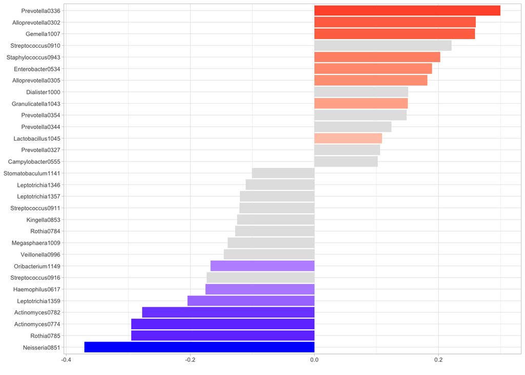

```r
impScores <- plsRes$coefficients[,,2]
load2plot <- impScores %>% as.matrix() %>% as.data.frame() %>% `colnames<-`("coef")
genera <- taxonomy_table[rownames(load2plot),"genus"]
OTUids <- gsub("OTU", "", rownames(load2plot))
rownames(load2plot) <- paste0(genera, OTUids)
p <- loadBarplot_v2(load2plot, comp = "coef", significant=sig, nfeat = 30, fsize = 7)
p
```

```r
ggsave("figs/coefPlot_global.png", width = 2, height = 2.5)
knockoff_ls<-list(data.frame(taxa=sig,positive=as.numeric(load2plot[sig,]>0)))
```

```r
plskoRes_group_path <- "output/plsko/group_list.qs"
dummy <- PhiSpace::codeY_vec(metaDat_c$cluster, rowNames = metaDat_c$id, method = "0,1")
nclust <- ncol(dummy)
if(!file.exists(plskoRes_group_path)){

  groupPLSKOres <- lapply(
    1:nclust, function(ii){
      patientClust <- metaDat_c$id[metaDat_c$cluster == ii]
      microbSub <- microb[,microb$id %in% patientClust]
      patientIDs <- intersect(rownames(metaDat), colnames(microbSub))
      X <- t(assay(microb, "data"))[patientIDs,] %>% as.matrix()
      X <- X[,colVars(X)>1e-10]
      Y <- metaDat[patientIDs,"OMscore_calib"]

      plsRes <- PLSKO::plsAKO(X, Y, ncores = 5, seed = 7639)
      sel <- names(plsRes$ako.s)
      genera <- taxonomy_table[sel,"genus"]
      OTUids <- gsub("OTU", "", sel)

      return(paste0(genera, OTUids))
    }
  )
  qsave(groupPLSKOres, plskoRes_group_path)
} else {

  groupPLSKOres <- qread(plskoRes_group_path)
}
```

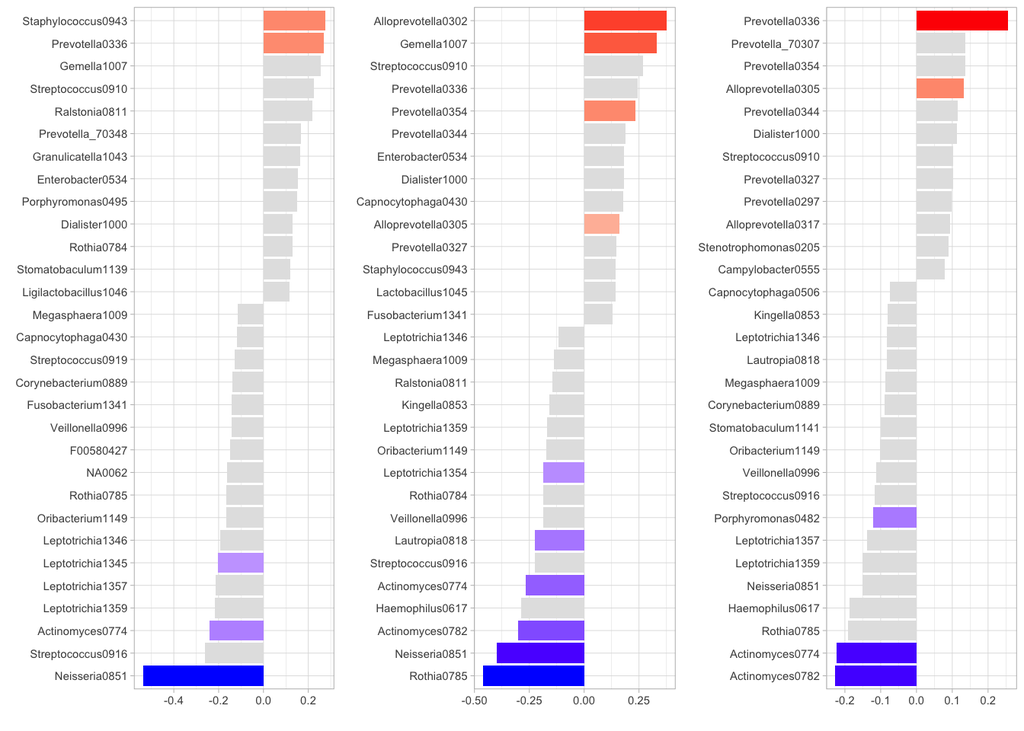

```r
groupPLSres <- lapply(
  1:nclust, function(ii){
    patientClust <- metaDat_c$id[metaDat_c$cluster == ii]
    microbSub <- microb[,microb$id %in% patientClust]
    patientIDs <- intersect(rownames(metaDat), colnames(microbSub))
    X <- t(assay(microb, "data"))[patientIDs,] %>% as.matrix()
    X <- X[,colVars(X)>1e-10]
    Y <- metaDat[patientIDs,"OMscore_calib"]

    plsRes <- PhiSpace::mvr(X, Y, ncomp = 2, method = "PLS", center = T)
    impScores <- plsRes$coefficients[,,2]
    load2plot <- impScores %>% as.matrix() %>% as.data.frame() %>% `colnames<-`("coef")
    genera <- taxonomy_table[rownames(load2plot),"genus"]
    OTUids <- gsub("OTU", "", rownames(load2plot))
    rownames(load2plot) <- paste0(genera, OTUids)
    sig<-groupPLSKOres[[ii]]
    knockoff_ls[[1+ii]]<<-data.frame(taxa=sig,positive=as.numeric(load2plot[sig,]>0))
    loadBarplot_v2(load2plot, comp = "coef", significant=sig, nfeat = 30, fsize = 7)
  }
)
p <- ggarrange(plotlist = groupPLSres, nrow = 1)
p
```

```r
ggsave("figs/coefPlot_group.png", width = 6, height = 2.5)
```

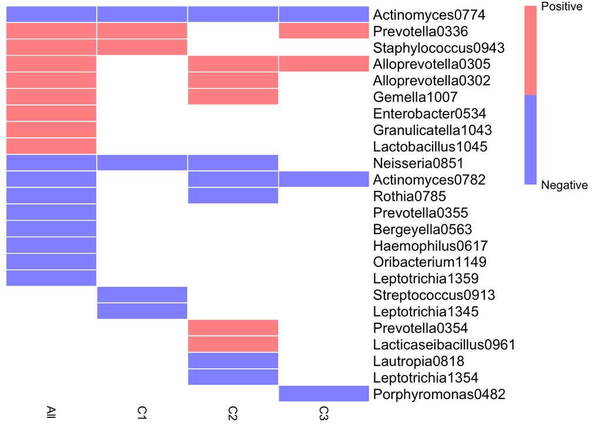

```r
# Combine knockoff_ls into a named list
knock_ls <- list(
  All = knockoff_ls[[1]],
  C1 = knockoff_ls[[2]],
  C2 = knockoff_ls[[3]],
  C3 = knockoff_ls[[4]]
)

# Get all unique taxa
all_taxa <- unique(unlist(lapply(knock_ls, function(x) x$taxa)))

# Create a matrix of values: 1 (positive), 0 (negative), NA (not selected)
taxa_matrix <- sapply(knock_ls, function(df) {
  out <- rep(NA, length(all_taxa))
  names(out) <- all_taxa
  out[df$taxa] <- df$positive
  out
})

# Reorder rows by same sorting logic
taxa_matrix <- taxa_matrix[order(
  -rowSums(taxa_matrix),
  -taxa_matrix[, "All"],
  -taxa_matrix[, "C1"],
  -taxa_matrix[, "C2"],
  -taxa_matrix[, "C3"]
), ]

png(filename = "figs/clusterTable.png",
width=6, height=6, units="in", res=150)
pheatmap::pheatmap(taxa_matrix,
                   color = c("#0000FF80", "#FF000080"),
                   legend_breaks = c(0, 1),
                   legend_labels = c("Negative", "Positive"),
                   cluster_rows = FALSE,
                   cluster_cols = FALSE,
                   fontsize_row = 12,
                   border_color = "white",
                   na_col = "white" )
```

```r
dev.off()
```

# Identifying patient characteristics that are associated with microbial abundance.

To investigate whether patient characteristics (such as age, height, and weight) and other factors (such as Timepoint and patient Cluster membership) were associated with microbial abundance, we applied linear mixed models (LMMs). LMMs extend standard linear models by including both fixed effects and random effects, making them particularly suitable for repeated-measures studies like this, which involve multiple observations from the same patient. In our models, age, height, weight, timepoint, and cluster were treated as fixed effects, while patients were modelled as random effects to account for dependencies in the data. We fitted separate LMMs for each taxon previously identified by PLSKO analysis as associated with the calibrated OM score, using CLR-transformed microbial abundance as the response variable.

```r
patientIDs <- intersect(rownames(metaDat), colnames(microb))
X <- t(assay(microb, "data"))[patientIDs,] %>% as.matrix()
colnames(X) <- paste0(taxonomy_table[colnames(X),"genus"], gsub("OTU", "", colnames(X)))

rownames(metaDat_c)<- rownames(metaDat)
microb_meta<-merge(metaDat_c[,c("id", "timepoint","cluster","OMscore_calib")],X[, all_taxa], by = "row.names")%>%
  merge(.,clFeat[c("id","sex", "weight", "bmi" , "heightnew"  ,"age")], by="id")

microb_meta$sex<-factor(microb_meta$sex, levels = c("1","2"),
                        labels=c("Female", "Male"))
```

```r
# Apply the model across all y's
models <- lapply(rownames(taxa_matrix), function(y) {
  formula <- as.formula(paste(y, "~ timepoint + cluster + age + heightnew + weight"))
  lme(formula, random = ~1 | id, data = microb_meta)
})
```

```r
mat<-sapply(models, function(x){v<-summary(x)
sign(v$tTable[-1,1])*(-log(v$tTable[-1,5]))}) %>% t()

rownames(mat)<- rownames(taxa_matrix)
```

```r
#-log(0.05)~3
# Define custom color function
# Define color function
col_fun <- colorRamp2(
  breaks = c(-100, -3, -2.9, 0, 2.9 , 3, 100),
  colors = c("darkorange4", "lightgoldenrod1", "grey","white","grey", "thistle1", "purple4")
)

# save the heatmap
png(filename = "figs/lmmRes.png",
width=6, height=6, units="in", res=150)
Heatmap(mat,
        name = "value",
        col = col_fun,
        cluster_rows = FALSE,
        cluster_columns = FALSE,
        show_row_dend = FALSE,
        show_column_dend = FALSE,
        rect_gp = gpar(col = "white", lwd = 2))
dev.off()
```